# Curve fitting: perspective from machine learning

杨小诺 2018011495 自83

```python
import numpy as np
import matplotlib.pyplot as plt
from sklearn import pipeline  # 多项式回归
from sklearn.linear_model import LinearRegression # 线性回归
from sklearn.preprocessing import PolynomialFeatures # 多项式特征构造模块
from sklearn.metrics import mean_squared_error # 均方误差
from sklearn.linear_model import SGDRegressor
from sklearn.preprocessing import StandardScaler
print("ok")
```

```
ok
```

## 问题（1）

以2℃作为间隔（步长），画出该种热敏电阻在温度范围为0℃~100℃间阻值随温度变化的特性曲线。

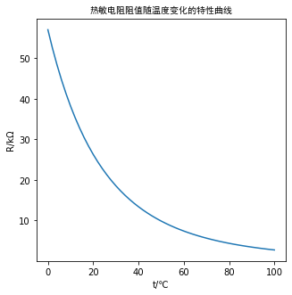

```python
t = []
R = []
for i in range(0,101,2):
    t.append(i)
    temp = 22 * np.exp(3100 * (1 / (273.15 + i) - 1 / (273.15 + 25)))
    R.append(temp)

# 画图
plt.figure()
plt.figure(figsize=(5,5))
plt.plot(t, R)
plt.xlabel('t/℃')
plt.ylabel('R/kΩ')
plt.title('热敏电阻阻值随温度变化的特性曲线',fontproperties='SimHei')
plt.show()
```

## 问题（2）

2.1 在（1）中获得的20℃-80℃范围的数据上添加适当噪声（以零均值、标准偏差取500的高斯噪声为例），用添加噪声后的数据模拟实验数据；  
2.2 用模拟的实验数据作为训练数据集，采用曲线拟合最小二乘法分别获得模型阶次n=1,2,3,4,5,6时传感器特性曲线对应的多项式模型；  
2.3 分别计算不同阶次模型在温度范围20℃-80℃（训练集）上和温度范围0℃~100℃刨除20℃-80℃温度范围后（测试集）上的误差（均方误差, mean squared error），观察训练集和测试集上误差随模型阶次的变化规律并加以讨论。

## 问题（3）

3）重复（2）相应内容10次（每次重新添加噪声模拟不同批次实验数据），观察并讨论由于采用不同训练数据给拟合（学习）结果带来的影响；

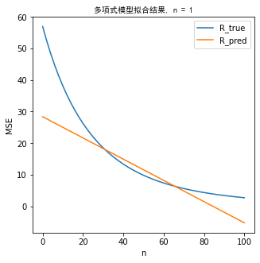

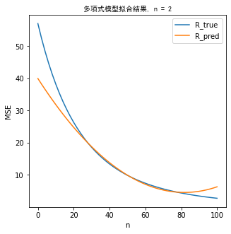

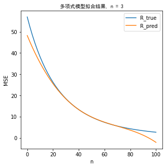

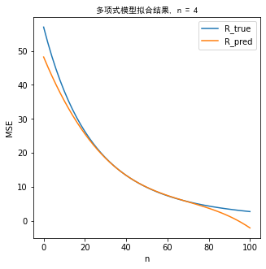

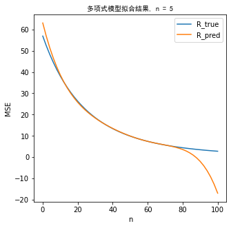

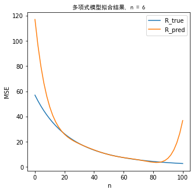

```
==============================================================================================
==============================问题（2），MSE随模型阶次的变化规律==============================
==============================================================================================
```

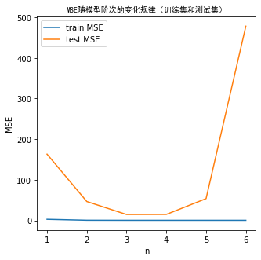

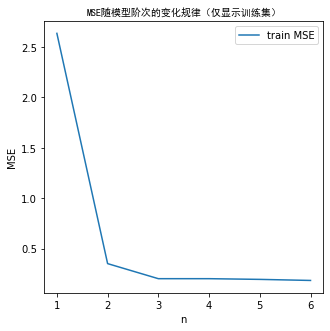

```
=============================================================================================
===========================问题（3），不同训练数据对拟合结果的影响===========================
=============================================================================================
```

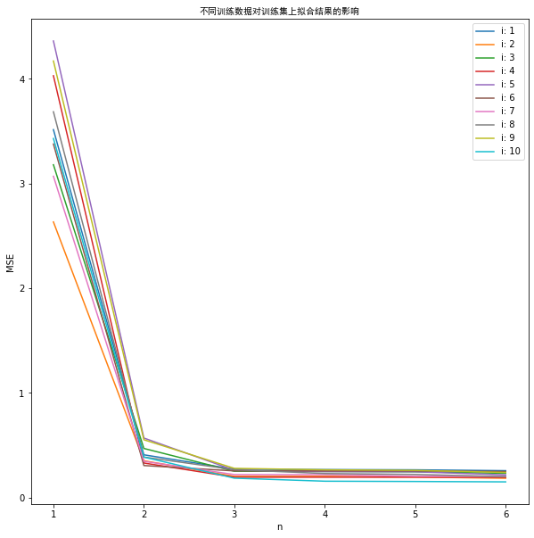

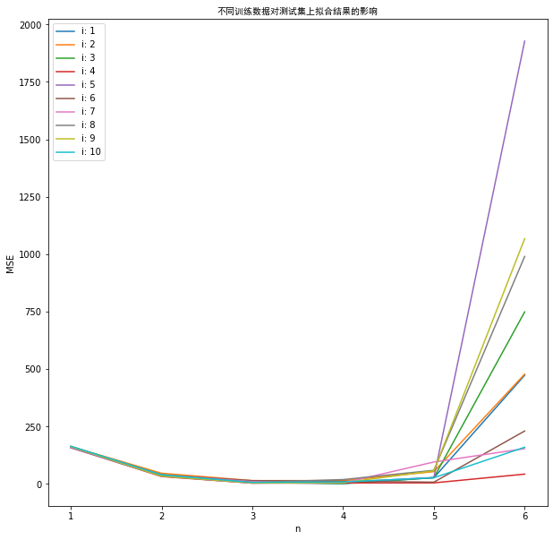

```python
# n = 1,2,3,4,5,6
# 每个阶次重复10次实验
train_MSE_500 = np.zeros([10,6])
test_MSE_500  = np.zeros([10,6])
for i in range(10):
    # 划分训练集和验证集
    x_train = t[list.index(t,20):list.index(t,80)+1] # 包含20和80
    y_train = R[list.index(t,20):list.index(t,80)+1]
    x_test  = t[:list.index(t,20)] + t[list.index(t,80)+1:]
    y_test  = R[:list.index(t,20)] + R[list.index(t,80)+1:]
    # 取高斯噪声
    noise = list(np.random.normal(loc = 0, scale = 0.5, size = len(y_train)))
    # 训练集加入噪声
    y_train = [y_train[i] + noise[i] for i in range(len(y_train))]

    # 最小二乘法拟合
    x_train = [[x_train[i]] for i in range(len(x_train))]
    y_train = [[y_train[i]] for i in range(len(y_train))]
    x_test  = [[x_test[i]]  for i in range(len(x_test))]
    y_test  = [[y_test[i]]  for i in range(len(y_test))]
    for n in range(1,7,1):
        # 多项式模型训练和预测
        model = pipeline.make_pipeline(PolynomialFeatures(n),LinearRegression())
        model.fit(x_train,y_train)
        p_train = model.predict(x_train)
        p_test  = model.predict(x_test)
        if i == 1:
            # 画图
            plt.figure()
            plt.figure(figsize=(5,5))
            xx = x_test[:a]+x_train+x_test[a:]
            p_train = list(p_train)
            p_test = list(p_test)
            yy = p_test[:a]+p_train+p_test[a:]
            plt.plot(t,R,label='R_true')
            plt.plot(xx,yy,label='R_pred')
            plt.legend()
            plt.xlabel('n')
            plt.ylabel('MSE')
            plt.title('多项式模型拟合结果, n = %d'% n, fontproperties='SimHei')
            fig = plt.gcf()
            plt.show()
            name = "q2_ans"+str(n)+".png"
            fig.savefig(name)
        # MSE计算
        train_MSE_500[i][n-1] = mean_squared_error(y_train,p_train)
        test_MSE_500[i][n-1]  = mean_squared_error(y_test,p_test)




print()
print()
print("==============================================================================================")
print("==============================问题（2），MSE随模型阶次的变化规律==============================")
print("==============================================================================================")
# 训练集和测试集上误差随模型阶次的变化规律
# 画图
plt.figure()
plt.figure(figsize=(5,5))
plt.plot( [i+1 for i in range(6)], train_MSE_500[1], label = 'train MSE')
plt.plot( [i+1 for i in range(6)], test_MSE_500[1], label = 'test MSE')
plt.legend()
plt.xlabel('n')
plt.ylabel('MSE')
plt.title('MSE随模型阶次的变化规律（训练集和测试集）',fontproperties='SimHei')
fig = plt.gcf()
plt.show()
name = "q2_MSE_all"+".png"
fig.savefig(name)
# 画图
plt.figure()
plt.figure(figsize=(5,5))
plt.plot( [i+1 for i in range(6)], train_MSE_500[1], label = 'train MSE')
plt.legend()
plt.xlabel('n')
plt.ylabel('MSE')
plt.title('MSE随模型阶次的变化规律（仅显示训练集）',fontproperties='SimHei')
fig = plt.gcf()
plt.show()
name = "q2_MSE_train"+".png"
fig.savefig(name)


print()
print()
print()
print()
print()
print()
print("=============================================================================================")
print("===========================问题（3），不同训练数据对拟合结果的影响===========================")
print("=============================================================================================")
# 画图
plt.figure()
plt.figure(figsize=(10,10))
lb = []
for i in range(10):
    plt.plot([n+1 for n in range(6)],train_MSE_500[i])
    lb.append("i: " + str(i+1))
plt.legend(lb)
plt.xlabel("n")
plt.ylabel('MSE')
plt.title('不同训练数据对训练集上拟合结果的影响',fontproperties='SimHei')
fig = plt.gcf()
plt.show()
name = "q3_MSE_train"+".png"
fig.savefig(name)

# 画图
plt.figure()
plt.figure(figsize=(10,10))
lb = []
for i in range(10):
    plt.plot([n+1 for n in range(6)],test_MSE_500[i])
    lb.append("i: " + str(i+1))
plt.legend(lb)
plt.xlabel("n")
plt.ylabel('MSE')
plt.title('不同训练数据对测试集上拟合结果的影响',fontproperties='SimHei')
fig = plt.gcf()
plt.show()
name = "q3_MSE_test"+".png"
fig.savefig(name)
```

## 问题（4）

改变噪声强度（通过改变所加噪声的标准偏差实现），重复（2），（3）内容，观察并讨论数据中不同噪声强度给拟合（学习）带来的影响。

```python
# n = 1,2,3,4,5,6
# 每个阶次重复10次实验
# 取3组不同的噪声强度（加问题（2）（3）共四组）

train_MSE = np.zeros([4,10,6])
test_MSE  = np.zeros([4,10,6])
train_MSE[1] = train_MSE_500
test_MSE[1]  = test_MSE_500
for i in range(10):
    sgm_cnt = 0
    for sgm in [0.1,1,10]:
        # 划分训练集和验证集
        x_train = t[list.index(t,20):list.index(t,80)+1] # 包含20和80
        y_train = R[list.index(t,20):list.index(t,80)+1]
        x_test  = t[:list.index(t,20)] + t[list.index(t,80)+1:]
        y_test  = R[:list.index(t,20)] + R[list.index(t,80)+1:]
        # 取高斯噪声
        noise = list(np.random.normal(loc = 0, scale = sgm, size = len(y_train)))
        # 训练集加入噪声
        y_train = [y_train[i] + noise[i] for i in range(len(y_train))]

        # 最小二乘法拟合
        x_train = [[x_train[i]] for i in range(len(x_train))]
        y_train = [[y_train[i]] for i in range(len(y_train))]
        x_test  = [[x_test[i]]  for i in range(len(x_test))]
        y_test  = [[y_test[i]]  for i in range(len(y_test))]
        for n in range(1,7,1):
            # 多项式模型训练和预测
            model = pipeline.make_pipeline(PolynomialFeatures(n),LinearRegression())
            model.fit(x_train,y_train)
            p_train = model.predict(x_train)
            p_test  = model.predict(x_test)
            # MSE计算
            train_MSE[sgm_cnt][i][n-1] = mean_squared_error(y_train,p_train)
            test_MSE[sgm_cnt][i][n-1]  = mean_squared_error(y_test,p_test)

        if sgm_cnt == 0:
            sgm_cnt += 2
        else:
            sgm_cnt += 1
```

```
=============================================================================================
===========================不同噪声强度下，MSE随模型阶次的变化规律===========================
=============================================================================================
```

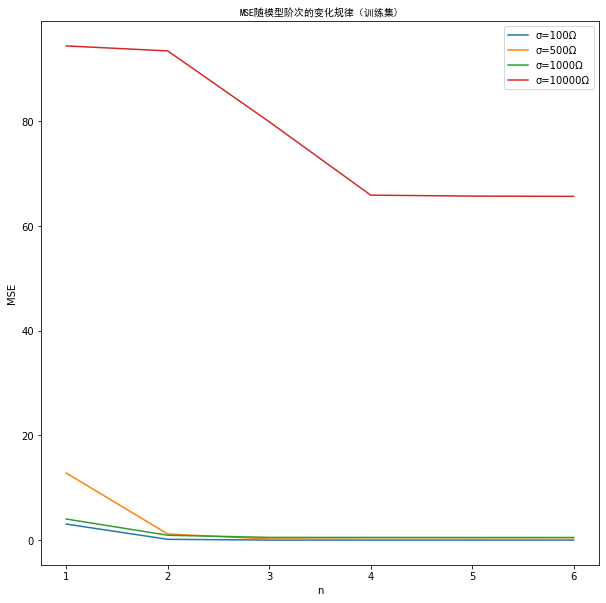

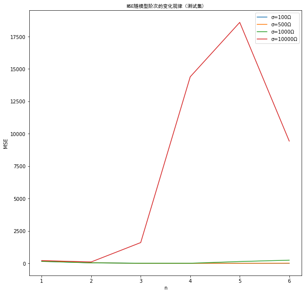

```
=============================================================================================
=========================不同噪声强度下，不同训练数据对拟合结果的影响========================
=============================================================================================


-----------------------------------------------------
------------------噪声标准差,  100 Ω--------------------
-----------------------------------------------------
```

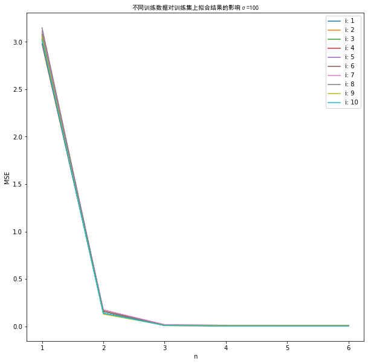

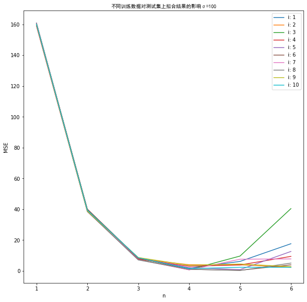

```
-----------------------------------------------------
------------------噪声标准差,  500 Ω--------------------
-----------------------------------------------------
```

[figure not shown]

[figure not shown]

```
-----------------------------------------------------
------------------噪声标准差,  1000 Ω--------------------
-----------------------------------------------------
```

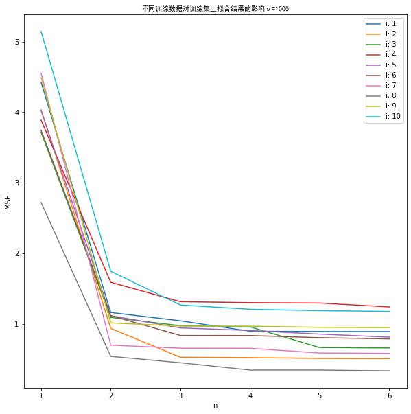

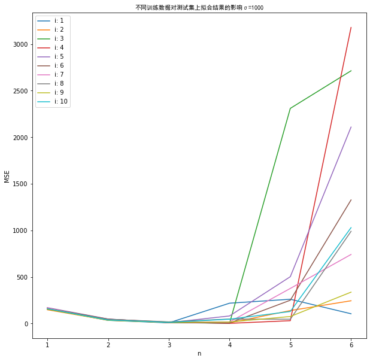

```
-----------------------------------------------------
------------------噪声标准差,  10000 Ω--------------------
-----------------------------------------------------
```

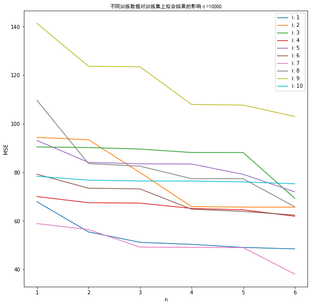

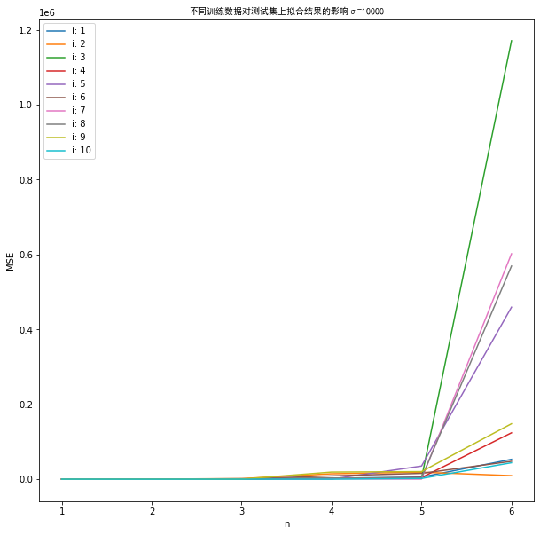

```python
print()
print()
print("=============================================================================================")
print("===========================不同噪声强度下，MSE随模型阶次的变化规律===========================")
print("=============================================================================================")
# 不同噪声强度下，训练集和测试集上误差随模型阶次的变化规律
plt.figure()
plt.figure(figsize=(10,10))
plt.plot([i+1 for i in range(6)],train_MSE[0][1], label = 'σ=100Ω')
plt.plot([i+1 for i in range(6)],train_MSE[1][1], label = 'σ=500Ω')
plt.plot([i+1 for i in range(6)],train_MSE[2][1], label = 'σ=1000Ω')
plt.plot([i+1 for i in range(6)],train_MSE[3][1], label = 'σ=10000Ω')
plt.legend()
plt.xlabel('n')
plt.ylabel('MSE')
plt.title('MSE随模型阶次的变化规律（训练集)',fontproperties='SimHei')
fig = plt.gcf()
plt.show()
name = "q4_MSE_train"+".png"
fig.savefig(name)

plt.figure()
plt.figure(figsize=(10,10))
plt.plot([i+1 for i in range(6)],test_MSE[0][1], label = 'σ=100Ω')
plt.plot([i+1 for i in range(6)],test_MSE[1][1], label = 'σ=500Ω')
plt.plot([i+1 for i in range(6)],test_MSE[2][1], label = 'σ=1000Ω')
plt.plot([i+1 for i in range(6)],test_MSE[3][1], label = 'σ=10000Ω')
plt.legend()
plt.xlabel('n')
plt.ylabel('MSE')
plt.title('MSE随模型阶次的变化规律（测试集)',fontproperties='SimHei')
fig = plt.gcf()
plt.show()
name = "q4_MSE_test"+".png"
fig.savefig(name)
print()
print()
print()
print()
print()
print()
print("=============================================================================================")
print("=========================不同噪声强度下，不同训练数据对拟合结果的影响========================")
print("=============================================================================================")
sgm = [100,500,1000,10000]
for sgm_cnt in range(4):
    print()
    print()
    print("-----------------------------------------------------")
    print("------------------噪声标准差, ",sgm[sgm_cnt],"Ω--------------------")
    print("-----------------------------------------------------")
    # 不同训练数据对训练集和测试集上拟合结果的影响
    # 画图
    plt.figure()
    plt.figure(figsize=(10,10))
    lb = []
    for i in range(10):
        plt.plot([n+1 for n in range(6)],train_MSE[sgm_cnt][i])
        lb.append("i: " + str(i+1))
        plt.legend(lb)
        plt.xlabel("n")
        plt.ylabel('MSE')
        tit = "不同训练数据对训练集上拟合结果的影响"+"σ="+str(sgm[sgm_cnt])
        plt.title(tit,fontproperties='SimHei')
    fig = plt.gcf()
    plt.show()
    name = "q4_MSE_train, σ="+str(sgm[sgm_cnt])+".png"
    fig.savefig(name)
    # 画图
    plt.figure()
    plt.figure(figsize=(10,10))
    lb = []
    for i in range(10):
        plt.plot([n+1 for n in range(6)],test_MSE[sgm_cnt][i])
        lb.append("i: " + str(i+1))
        plt.legend(lb)
        plt.xlabel("n")
        plt.ylabel('MSE')
        tit = "不同训练数据对测试集上拟合结果的影响"+"σ="+str(sgm[sgm_cnt])
        plt.title(tit,fontproperties='SimHei')
    fig = plt.gcf()
    plt.show()
    name = "q4_MSE_test, σ="+str(sgm[sgm_cnt])+".png"
    fig.savefig(name)
```

## 问题（5）

将实验数据温度20℃-80℃范围进行调整（扩大或缩小），重复（2），（3）内容（需要对训练集及测试集范围进行对应调整），观察并讨论由于采用不同规模训练数据给拟合（学习）结果带来的影响。

将训练集调整至：10℃-90℃

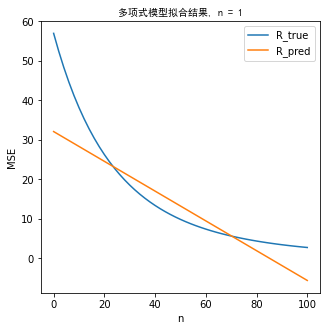

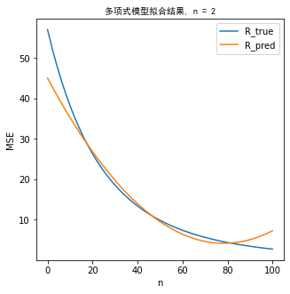

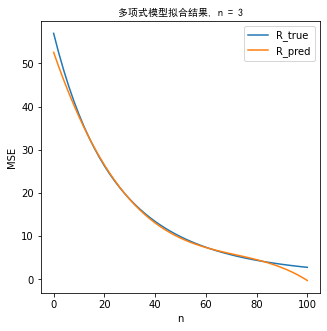

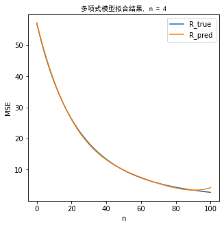

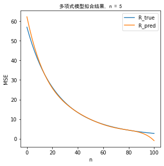

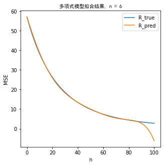

```python
# n = 1,2,3,4,5,6
# 每个阶次重复10次实验
train_MSE_500 = np.zeros([10,6])
test_MSE_500  = np.zeros([10,6])
for i in range(10):
    # 划分训练集和验证集
    x_train = t[list.index(t,10):list.index(t,90)+1] # 包含20和80
    y_train = R[list.index(t,10):list.index(t,90)+1]
    x_test  = t[:list.index(t,10)] + t[list.index(t,90)+1:]
    y_test  = R[:list.index(t,10)] + R[list.index(t,90)+1:]
    # 取高斯噪声
    noise = list(np.random.normal(loc = 0, scale = 0.5, size = len(y_train)))
    # 训练集加入噪声
    y_train = [y_train[i] + noise[i] for i in range(len(y_train))]

    # 最小二乘法拟合
    x_train = [[x_train[i]] for i in range(len(x_train))]
    y_train = [[y_train[i]] for i in range(len(y_train))]
    x_test  = [[x_test[i]]  for i in range(len(x_test))]
    y_test  = [[y_test[i]]  for i in range(len(y_test))]
    for n in range(1,7,1):
        # 多项式模型训练和预测
        model = pipeline.make_pipeline(PolynomialFeatures(n),LinearRegression())
        model.fit(x_train,y_train)
        p_train = model.predict(x_train)
        p_test  = model.predict(x_test)
        if i == 1:
            # 画图
            plt.figure()
            plt.figure(figsize=(5,5))
            a = list.index(t,10)
            xx = x_test[:a]+x_train+x_test[a:]
            p_train = list(p_train)
            p_test = list(p_test)
            yy = p_test[:a]+p_train+p_test[a:]
            plt.plot(t,R,label='R_true')
            plt.plot(xx,yy,label='R_pred')
            plt.legend()
            plt.xlabel('n')
            plt.ylabel('MSE')
            plt.title('多项式模型拟合结果, n = %d'% n, fontproperties='SimHei')
            fig = plt.gcf()
            plt.show()
            name = "q5_ans_n"+str(n)+".png"
            fig.savefig(name)
        # MSE计算
        train_MSE_500[i][n-1] = mean_squared_error(y_train,p_train)
        test_MSE_500[i][n-1]  = mean_squared_error(y_test,p_test)
```

```
=============================================================================================
==========================改变训练集范围后，MSE随模型阶次的变化规律==========================
=============================================================================================
```

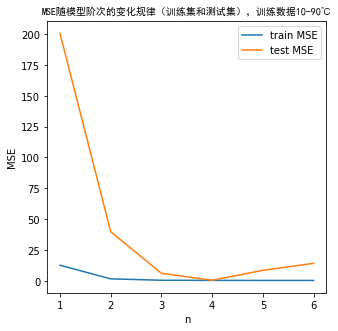

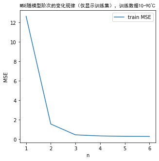

```
=============================================================================================
========================改变训练集范围后，不同训练数据对拟合结果的影响=======================
=============================================================================================
```

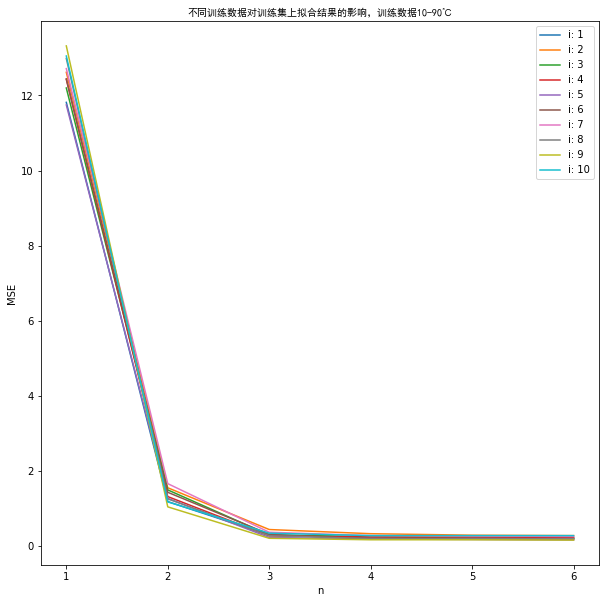

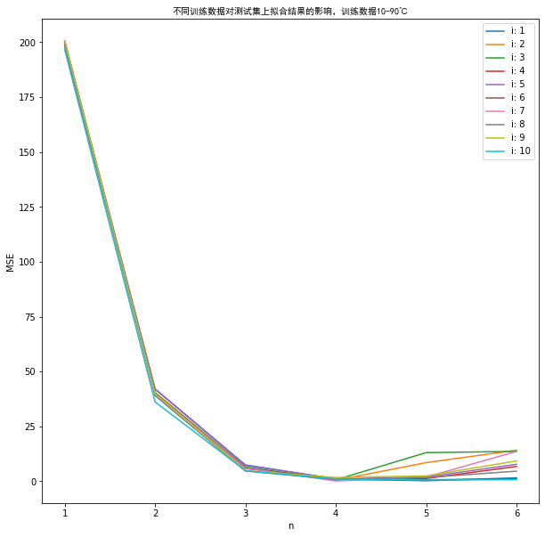

```python
print()
print()
print("=============================================================================================")
print("==========================改变训练集范围后，MSE随模型阶次的变化规律==========================")
print("=============================================================================================")
# 训练集和测试集上误差随模型阶次的变化规律
# 画图
plt.figure()
plt.figure(figsize=(5,5))
plt.plot( [i+1 for i in range(6)], train_MSE_500[1], label = 'train MSE')
plt.plot( [i+1 for i in range(6)], test_MSE_500[1], label = 'test MSE')
plt.legend()
plt.xlabel('n')
plt.ylabel('MSE')
plt.title('MSE随模型阶次的变化规律（训练集和测试集），训练数据10-90℃',fontproperties='SimHei')
fig = plt.gcf()
plt.show()
name = "q5_2_MSE_all_1090"+".png"
fig.savefig(name)

plt.figure()
plt.figure(figsize=(5,5))
plt.plot( [i+1 for i in range(6)], train_MSE_500[1], label = 'train MSE')
plt.legend()
plt.xlabel('n')
plt.ylabel('MSE')
plt.title('MSE随模型阶次的变化规律（仅显示训练集），训练数据10-90℃',fontproperties='SimHei')
fig = plt.gcf()
plt.show()
name = "q5_2_MSE_train_1090"+".png"
fig.savefig(name)


print("=============================================================================================")
print("========================改变训练集范围后，不同训练数据对拟合结果的影响=======================")
print("=============================================================================================")
# 画图
plt.figure()
plt.figure(figsize=(10,10))
lb = []
for i in range(10):
    plt.plot([n+1 for n in range(6)],train_MSE_500[i])
    lb.append("i: " + str(i+1))
plt.legend(lb)
plt.xlabel("n")
plt.ylabel('MSE')
plt.title('不同训练数据对训练集上拟合结果的影响，训练数据10-90℃',fontproperties='SimHei')
fig = plt.gcf()
plt.show()
name = "q5_3_MSE_train_1090"+".png"
fig.savefig(name)

# 画图
plt.figure()
plt.figure(figsize=(10,10))
lb = []
for i in range(10):
    plt.plot([n+1 for n in range(6)],test_MSE_500[i])
    lb.append("i: " + str(i+1))
plt.legend(lb)
plt.xlabel("n")
plt.ylabel('MSE')
plt.title('不同训练数据对测试集上拟合结果的影响，训练数据10-90℃',fontproperties='SimHei')
fig = plt.gcf()
plt.show()
name = "q5_3_MSE_test_1090"+".png"
fig.savefig(name)
```

## 问题（5）

范围30-70℃

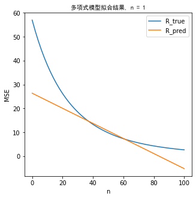

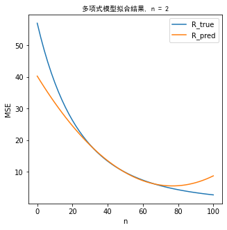

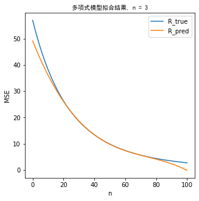

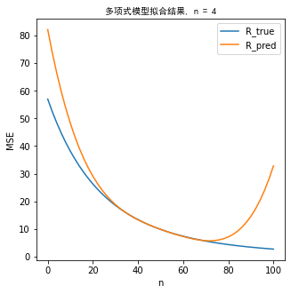

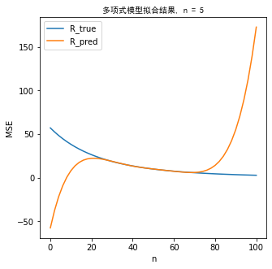

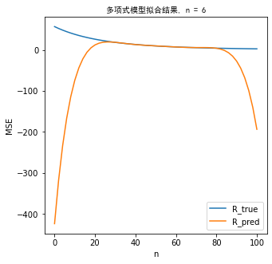

```python
# n = 1,2,3,4,5,6
# 每个阶次重复10次实验
train_MSE_500 = np.zeros([10,6])
test_MSE_500  = np.zeros([10,6])
for i in range(10):
    # 划分训练集和验证集
    x_train = t[list.index(t,30):list.index(t,70)+1] # 包含20和80
    y_train = R[list.index(t,30):list.index(t,70)+1]
    x_test  = t[:list.index(t,30)] + t[list.index(t,70)+1:]
    y_test  = R[:list.index(t,30)] + R[list.index(t,70)+1:]
    # 取高斯噪声
    noise = list(np.random.normal(loc = 0, scale = 0.5, size = len(y_train)))
    # 训练集加入噪声
    y_train = [y_train[i] + noise[i] for i in range(len(y_train))]

    # 最小二乘法拟合
    x_train = [[x_train[i]] for i in range(len(x_train))]
    y_train = [[y_train[i]] for i in range(len(y_train))]
    x_test  = [[x_test[i]]  for i in range(len(x_test))]
    y_test  = [[y_test[i]]  for i in range(len(y_test))]
    for n in range(1,7,1):
        # 多项式模型训练和预测
        model = pipeline.make_pipeline(PolynomialFeatures(n),LinearRegression())
        model.fit(x_train,y_train)
        p_train = model.predict(x_train)
        p_test  = model.predict(x_test)
        if i == 1:
            # 画图
            plt.figure()
            plt.figure(figsize=(5,5))
            a = list.index(t,30)
            xx = x_test[:a]+x_train+x_test[a:]
            p_train = list(p_train)
            p_test = list(p_test)
            yy = p_test[:a]+p_train+p_test[a:]
            plt.plot(t,R,label='R_true')
            plt.plot(xx,yy,label='R_pred')
            plt.legend()
            plt.xlabel('n')
            plt.ylabel('MSE')
            plt.title('多项式模型拟合结果, n = %d'% n, fontproperties='SimHei')
            fig = plt.gcf()
            plt.show()
            name = "q5_ans_n"+str(n)+"_3070.png"
            fig.savefig(name)
        # MSE计算
        train_MSE_500[i][n-1] = mean_squared_error(y_train,p_train)
        test_MSE_500[i][n-1]  = mean_squared_error(y_test,p_test)
```

```
=============================================================================================
==========================改变训练集范围后，MSE随模型阶次的变化规律==========================
=============================================================================================
```

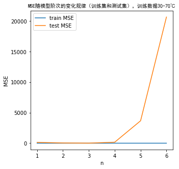

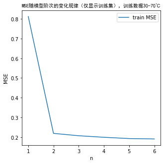

```
=============================================================================================
========================改变训练集范围后，不同训练数据对拟合结果的影响=======================
=============================================================================================
```

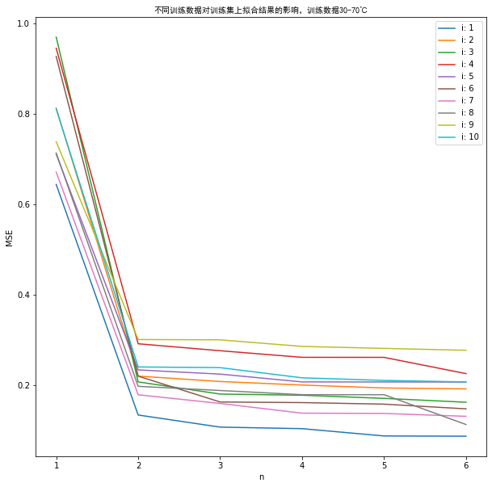

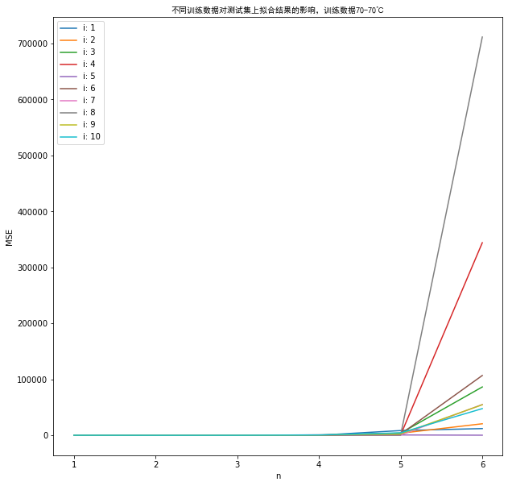

```python
print()
print()
print("=============================================================================================")
print("==========================改变训练集范围后，MSE随模型阶次的变化规律==========================")
print("=============================================================================================")
# 训练集和测试集上误差随模型阶次的变化规律
# 画图
plt.figure()
plt.figure(figsize=(5,5))
plt.plot( [i+1 for i in range(6)], train_MSE_500[1], label = 'train MSE')
plt.plot( [i+1 for i in range(6)], test_MSE_500[1], label = 'test MSE')
plt.legend()
plt.xlabel('n')
plt.ylabel('MSE')
plt.title('MSE随模型阶次的变化规律（训练集和测试集），训练数据30-70℃',fontproperties='SimHei')
fig = plt.gcf()
plt.show()
name = "q5_2_MSE_all_3070"+".png"
fig.savefig(name)

plt.figure()
plt.figure(figsize=(5,5))
plt.plot( [i+1 for i in range(6)], train_MSE_500[1], label = 'train MSE')
plt.legend()
plt.xlabel('n')
plt.ylabel('MSE')
plt.title('MSE随模型阶次的变化规律（仅显示训练集），训练数据30-70℃',fontproperties='SimHei')
fig = plt.gcf()
plt.show()
name = "q5_2_MSE_train_3070"+".png"
fig.savefig(name)


print("=============================================================================================")
print("========================改变训练集范围后，不同训练数据对拟合结果的影响=======================")
print("=============================================================================================")
# 画图
plt.figure()
plt.figure(figsize=(10,10))
lb = []
for i in range(10):
    plt.plot([n+1 for n in range(6)],train_MSE_500[i])
    lb.append("i: " + str(i+1))
plt.legend(lb)
plt.xlabel("n")
plt.ylabel('MSE')
plt.title('不同训练数据对训练集上拟合结果的影响，训练数据30-70℃',fontproperties='SimHei')
fig = plt.gcf()
plt.show()
name = "q5_3_MSE_train_3070"+".png"
fig.savefig(name)

# 画图
plt.figure()
plt.figure(figsize=(10,10))
lb = []
for i in range(10):
    plt.plot([n+1 for n in range(6)],test_MSE_500[i])
    lb.append("i: " + str(i+1))
plt.legend(lb)
plt.xlabel("n")
plt.ylabel('MSE')
plt.title('不同训练数据对测试集上拟合结果的影响，训练数据70-70℃',fontproperties='SimHei')
fig = plt.gcf()
plt.show()
name = "q5_3_MSE_test_3070"+".png"
fig.savefig(name)
```

## 问题（6）

```
=============================================================================================
==========================改变训练集范围后，MSE随模型阶次的变化规律==========================
=============================================================================================
```

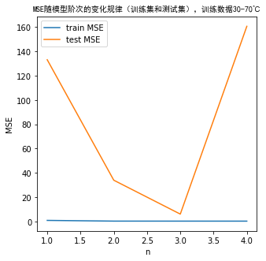

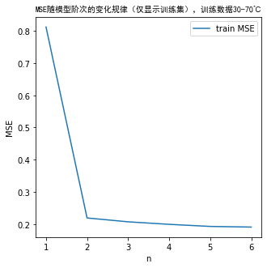

```python
print()
print()
print("=============================================================================================")
print("==========================改变训练集范围后，MSE随模型阶次的变化规律==========================")
print("=============================================================================================")
# 训练集和测试集上误差随模型阶次的变化规律
# 画图
plt.figure()
plt.figure(figsize=(5,5))
a = [train_MSE_500[1][0],train_MSE_500[1][1],train_MSE_500[1][2],train_MSE_500[1][3]]
b = [test_MSE_500[1][0],test_MSE_500[1][1],test_MSE_500[1][2],test_MSE_500[1][3]]
plt.plot( [[i+1] for i in range(4)], a, label = 'train MSE')
plt.plot( [[i+1] for i in range(4)], b, label = 'test MSE')
plt.legend()
plt.xlabel('n')
plt.ylabel('MSE')
plt.title('MSE随模型阶次的变化规律（训练集和测试集），训练数据30-70℃',fontproperties='SimHei')
fig = plt.gcf()
plt.show()
name = "t1"+".png"
fig.savefig(name)

plt.figure()
plt.figure(figsize=(5,5))
plt.plot( [i+1 for i in range(6)], train_MSE_500[1], label = 'train MSE')
plt.legend()
plt.xlabel('n')
plt.ylabel('MSE')
plt.title('MSE随模型阶次的变化规律（仅显示训练集），训练数据30-70℃',fontproperties='SimHei')
fig = plt.gcf()
plt.show()
name = "t2"+".png"
fig.savefig(name)
```

## 问题（7）

思考：假如实验前已事先了解热敏电阻测温机理并掌握其阻值与温度的关系符合（1）式所描述的模型，你将如何考虑从实验数据获得热敏电阻的阻值与温度关系模型？

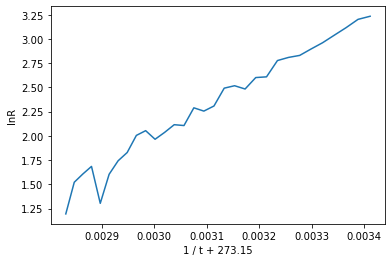

```
y = 3226.0671403688234 x + ( -7.717475966241418 )
```

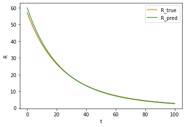

```python
# 划分训练集和验证集
x_train = t[list.index(t,20):list.index(t,80)+1] # 包含20和80
y_train = R[list.index(t,20):list.index(t,80)+1]
x_test  = t[:list.index(t,20)] + t[list.index(t,80)+1:]
y_test  = R[:list.index(t,20)] + R[list.index(t,80)+1:]
# 取高斯噪声
noise = list(np.random.normal(loc = 0, scale = 0.5, size = len(y_train)))
# 训练集加入噪声
y_train = [y_train[i] + noise[i] for i in range(len(y_train))]

# 变形
x_train_new = [[1 / (item + 273.15)] for item in x_train]
y_train_new = [[np.log(item)] for item in y_train]
x_test_new = [[1 / (item + 273.15)] for item in x_test]
plt.plot(x_train_new,y_train_new)
plt.xlabel('1 / t + 273.15')
plt.ylabel('lnR')
fig = plt.gcf()
plt.show()
name = "q7_2"+".png"
fig.savefig(name)
# 线性回归
model = LinearRegression().fit(x_train_new, y_train_new)

y_train_pred = model.predict(x_train_new)
y_train_pred = np.exp(y_train_pred)
y_test_pred = model.predict(x_test_new)
y_test_pred = np.exp(y_test_pred)

# 拟合直线
k = model.coef_[0][0]
para = model.intercept_[0]
print('y =',str(k),'x + (',str(para),')')


# 画图

plt.plot(t,R)

a = list.index(t,20)
y_train = list(y_train)
t_temp = []
tt = []
for i in range(y_train_pred.shape[0]):
    tt.append(y_train_pred[i][0])
for i in range(y_test_pred.shape[0]):
    t_temp.append(y_test_pred[i][0])

xx = x_test[:a]      + x_train + x_test[a:]

yy = t_temp[:a]      + tt + t_temp[a:]

plt.plot(t,R,label='R_true')
plt.plot(xx,yy,label='R_pred')

plt.xlabel('t')
plt.ylabel('R')
plt.legend()
fig = plt.gcf()
plt.show()
name = "q7_1"+".png"
fig.savefig(name)
```